# BirthWeight

Debasis Roy

May 12, 2019

## Q.4 Risk factors for low infant birth weight

4. Risk factors for low infant birth weight: The data set birthwt in the MASS package gives data on 189 babies born at Baystate Medical Center, Springfield, MA during 1986. The quantitative response is bwt (birth weight in grams), and this is also recorded as low, a binary variable corresponding to bwt < 2500 (2.5 Kg). The goal is to study how this varies with the available predictor variables. The variables are all recorded as numeric, so in R it may be helpful to convert some of these into factors and possibly collapse some low frequency categories. The code below is just an example of how you might do this for some variables.

```r
birthwt2 <- within(birthwt, {
race <- factor(race, labels = c("white", "black", "other"))
 ptd <- factor(ptl > 0)
 ftv <- factor(ftv)
 levels(ftv)[-(1:2)] <- "2+"
 smoke <- factor(smoke>0)
 ht <- factor(ht>0)
 ui <- factor(ui>0)
})
```

1. Make some exploratory plots showing how low birth weight varies with each of the available predictors. In some cases, it will probably be helpful to add some sort of smoothed summary curves or lines.

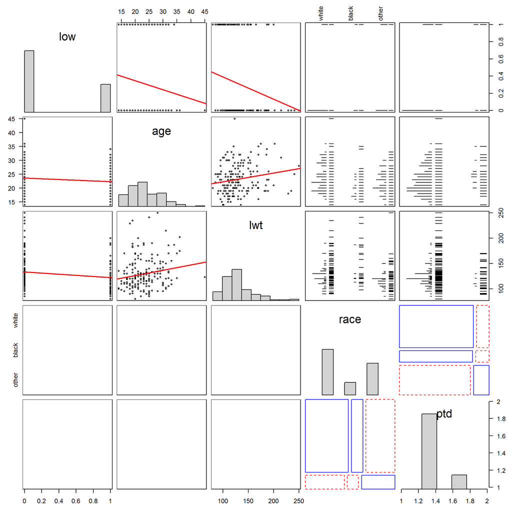

```r
vars <- c("low", "age", "lwt", "race", "ptd")
gpairs(birthwt2[,vars],
diag.pars=list(fontsize=16, hist.color="lightgray"), lower.pars = list(scatter="lm"),
upper.pars = list(scatter="lm"),
mosaic.pars=list(gp=shading_Friendly,
gp_args=list(interpolate=1:4)))
```

2. Fit several logistic regression models predicting low birth weight from these predictors, with the goal of explaining this phenomenon adequately, yet simply.

```r
bweight.m0 <- glm(low ~ age + lwt + race + smoke + ptd + ht + ui + ftv, data=birthwt2, family = binomial)
summary(bweight.m0)
```

```
##
## Call:
## glm(formula = low ~ age + lwt + race + smoke + ptd + ht + ui +
##     ftv, family = binomial, data = birthwt2)
##
## Deviance Residuals:
##    Min      1Q  Median      3Q     Max
## -1.704  -0.807  -0.501   0.884   2.215
##
## Coefficients:
##             Estimate Std. Error z value Pr(>|z|)
## (Intercept)  0.82302    1.24471    0.66   0.5085
## age         -0.03723    0.03870   -0.96   0.3360
## lwt         -0.01565    0.00708   -2.21   0.0271 *
## raceblack    1.19241    0.53596    2.22   0.0261 *
## raceother    0.74068    0.46174    1.60   0.1087
## smokeTRUE    0.75553    0.42502    1.78   0.0755 .
## ptdTRUE      1.34376    0.48062    2.80   0.0052 **
## htTRUE       1.91317    0.72074    2.65   0.0079 **
## uiTRUE       0.68020    0.46434    1.46   0.1430
## ftv1        -0.43638    0.47939   -0.91   0.3627
## ftv2+        0.17901    0.45638    0.39   0.6949
## ---
## Signif. codes:  0 '***' 0.001 '**' 0.01 '*' 0.05 '.' 0.1 ' ' 1
##
## (Dispersion parameter for binomial family taken to be 1)
##
##     Null deviance: 234.67  on 188  degrees of freedom
## Residual deviance: 195.48  on 178  degrees of freedom
## AIC: 217.5
##
## Number of Fisher Scoring iterations: 4
```

```r
car::Anova(bweight.m0)
```

```
## Analysis of Deviance Table (Type II tests)
##
## Response: low
##       LR Chisq Df Pr(>Chisq)
## age       0.94  1     0.3318
## lwt       5.47  1     0.0193 *
## race      5.75  2     0.0564 .
## smoke     3.20  1     0.0737 .
## ptd       8.11  1     0.0044 **
## ht        7.46  1     0.0063 **
## ui        2.11  1     0.1463
## ftv       1.36  2     0.5071
## ---
## Signif. codes:  0 '***' 0.001 '**' 0.01 '*' 0.05 '.' 0.1 ' ' 1
```

```r
bweight.m1 <- update(bweight.m0, . ~ . - ui - ftv)
Anova(bweight.m1)
```

```
## Analysis of Deviance Table (Type II tests)
##
## Response: low
##       LR Chisq Df Pr(>Chisq)
## age       1.33  1     0.2487
## lwt       5.40  1     0.0201 *
## race      6.24  2     0.0441 *
## smoke     4.62  1     0.0316 *
## ptd       8.73  1     0.0031 **
## ht        6.46  1     0.0111 *
## ---
## Signif. codes:  0 '***' 0.001 '**' 0.01 '*' 0.05 '.' 0.1 ' ' 1
```

```r
anova(bweight.m1, bweight.m0, test="Chisq")
```

```
## Analysis of Deviance Table
##
## Model 1: low ~ age + lwt + race + smoke + ptd + ht
## Model 2: low ~ age + lwt + race + smoke + ptd + ht + ui + ftv
##   Resid. Df Resid. Dev Df Deviance Pr(>Chi)
## 1       181        199
## 2       178        196  3     3.68      0.3
```

3. Use some graphical displays to convey your findings.

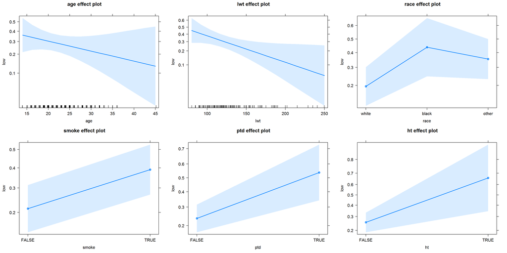

```r
plot(allEffects(bweight.m1), ci.style="bands")
```